# Lending Club Capstone Final

Minh Truong

October 1, 2016

## Lending Club (LC)

Lending Club is a new Peer2Peer Platform that connects lenders with borrowers (think Kickstarter for personal loans). LC uses an algorithm model to decide on the risk level or interest rate borrowers need to be charged lenders. Rates are made to be easy to apply and lending club charges a fee to finance for borrowers and charges lender’s fees for the services rendered.

*PROBLEM:*

http://www.bloomberg.com/news/features/2016-08-18/how-lending-club-s-biggest-fanboy-uncovered-shady-loans

*Recently there has been a scandal where some borrowers may be the same borrowers and some anomalies were found.* Stock price has lost 2/3 of its value $15 to $5 almost overnight.

*TLDR; BAD LOANS ARE AFFECTING the STOCK PRICE AND PROFITABILITY LENDING CLUB*

*ISSUES/CHALLENGES:*

1. Can bad loans be identified before being accepted into the system?
2. What are the characteristics of a bad loan? Are there tell-tail signs?
3. What are the short/long term strategies after successful identifying?
4. What are other potential areas to improve or look at?
5. Are there are interesting or weird issues?

*FINDINGS:*

1. YES it is possible to make a bad loans model that can identify bad loans.
2. We are looking for any patterns, unusual clumping or clues on why it won’t look like a normal healthy population distribution.
3. Implement ways to mitigate short term risks with accelerated payment inventives with longer term strategy to uncover hidden risks that look safe.
4. Can look at ways to run a linear regression on the top variables to improve bad loans model
5. Originally I was expecting the types of variables that would signal being unable to pay like credit inquiries, delinquencies, income, interest rates but what I found were variables that seem to signify people who would be a great credit risk but but had hidden circumstances that may or may not show up in the data directly and if they showed it would be indirect proof.

*DATA:*

URL: https://www.lendingclub.com/info/download-data.action

The dataset is HUGE 421k loans and 115 possible variables/features not counting features we can add

Since it is very time consuming to try all the combinations and nor do we want to build a model with too many variables as it will make the model unnecessarily complicated and the danger of overfitting the data.

Issue with overfitting would mean it explains the current data set but has poor predictability for new datasets.

Also since we have many observations and many variables the strategy will best to take advantage of what is available and try to extract as much value thats existing before trying anything too fancy.

STARTING WITH THE USUAL CUPRITS THAT MAY FIT (Who are the ones that we need to get?)

*Keep in mind most households have 15K in credit card debt, with many with auto loans, mortgages, student loans and other debt*

So It isn’t unusual to borrow money but the clue is to if certain characteristics are overweighted that shouldnt be.

Some easy ones that come to mind are low income type loans, or high interest type loans, or people who carry an unusual balance loads/acconts or flags like credit inquires or past delinquencies that signal I may not pay.

```r
suppressWarnings(suppressMessages(library(ggplot2)))
suppressWarnings(suppressMessages(library(dplyr)))
suppressWarnings(suppressMessages(library(tidyr)))
suppressWarnings(suppressMessages(library(lubridate)))
suppressWarnings(suppressMessages(library(caTools)))
suppressWarnings(suppressMessages(library(ROCR)))
suppressWarnings(suppressMessages(library(pROC)))

LC <- read.csv("LoanStats3d_securev1.csv")
summary(LC$loan_status)
```

```
##        Charged Off            Current            Default
##              13325             336267                539
##         Fully Paid    In Grace Period  Late (16-30 days)
##              55905               3974               2515
## Late (31-120 days)
##               8570
```

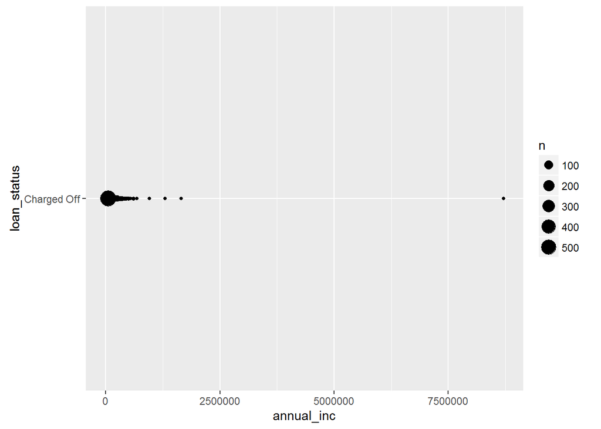

```r
#Top reason many will say why they couldnt pay is "I don't make enough money", but #looking at the data set, there doesnt seem to be any huge defaults on the low end nor #the high end. Looking at the distribution quartiles, they look like income low or high #they default/charge off equally as likely, next most likely may be the interest rate, #"I got charged too much! Lets take a look."*

annual <- subset(LC,select = c("loan_status","annual_inc") )
annual_2 <- subset(annual, loan_status == "Charged Off")
ggplot(annual_2, aes (x = annual_inc, y =loan_status ))+geom_count()
```

```r
summary(annual_2)
```

```
##              loan_status      annual_inc
##  Charged Off       :13325   Min.   :      0
##  Current           :    0   1st Qu.:  42000
##  Default           :    0   Median :  60000
##  Fully Paid        :    0   Mean   :  69714
##  In Grace Period   :    0   3rd Qu.:  82800
##  Late (16-30 days) :    0   Max.   :8706582
##  Late (31-120 days):    0
```

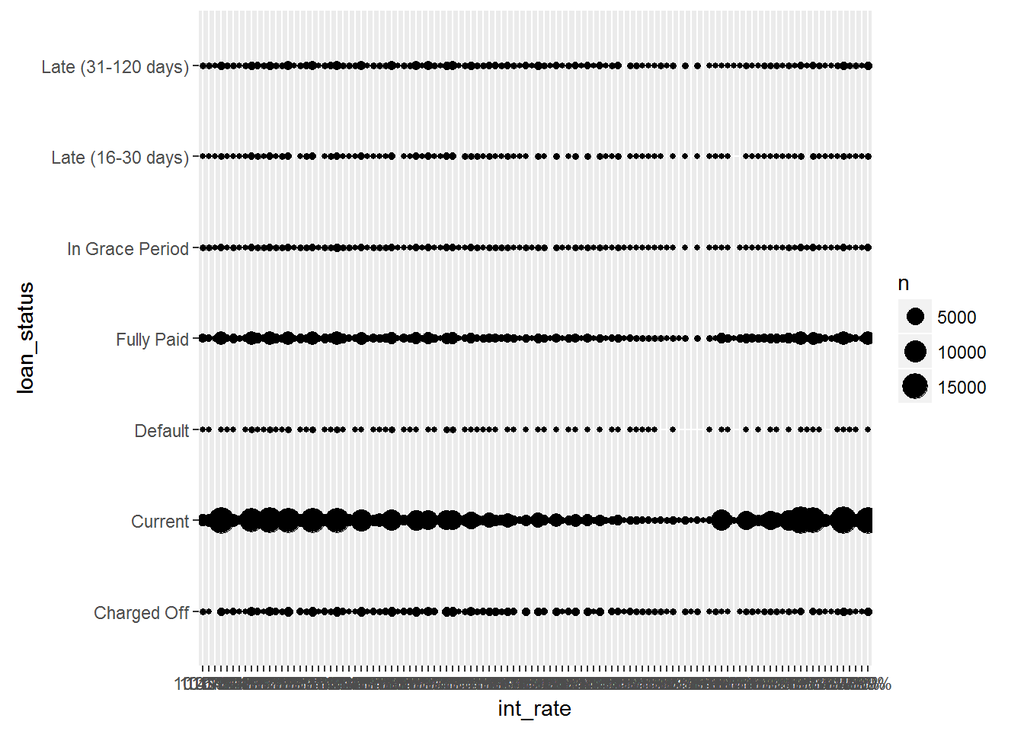

```r
#Interest Rate seems like a good starting point, but doesn't seem to be a pattern, #there doesn't seem to be any unusual weights anywhere and seems fairly distributed #around. Lets see if having a job is the reason!

int_rate.loan_status <- subset(LC,select = c("loan_status","int_rate") )
ggplot(int_rate.loan_status, aes( x= int_rate, y = loan_status))+ geom_count()
```

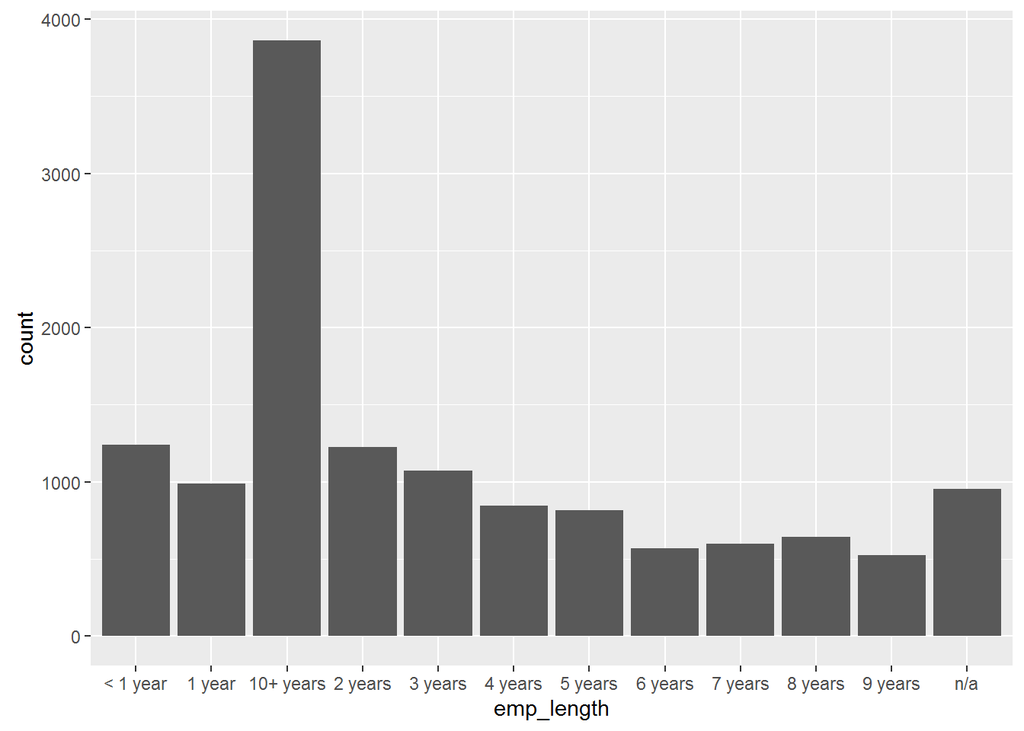

```r
#Looks like employment length have alot of defaults with those @ 10+ Years, which is #unusual as those who are employed the longest tend to be responsible and consistent #or else they wouldnt be employed for so long. So this may be a clue on why. Lets see #if there are any delinquencies or credit inquiries.

emp_length <- subset(LC,select= c("loan_status","emp_length") )
emp_length_3 <- subset(emp_length, loan_status == "Charged Off")
emp_length_3 <- subset(emp_length, loan_status == "Charged Off")
ggplot(emp_length_3,aes(x= emp_length )) + geom_bar()
```

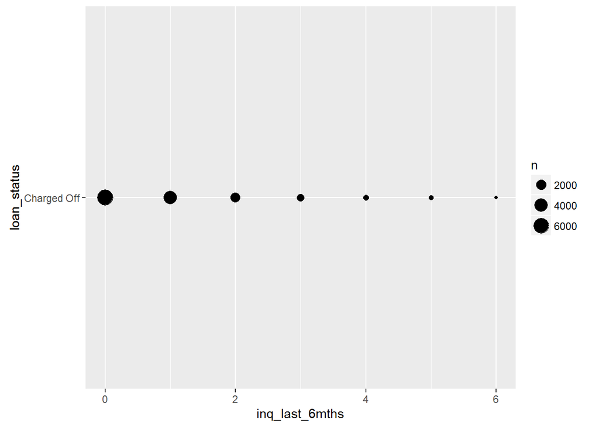

```r
# Looks like an unusual of charge offs at 0 or 1 inquiries meaning most of the people #had few credit card binge opening, maybe they didnt open any new credit lines but  #started to fall behind the ones they already have open. Lets find out!

inq_6mths <- subset(LC,select = c("loan_status","inq_last_6mths") )
inq_6mths_2 <- subset(inq_6mths, loan_status == "Charged Off")
ggplot(inq_6mths_2, aes (x = inq_last_6mths, y =loan_status ))+geom_count()
```

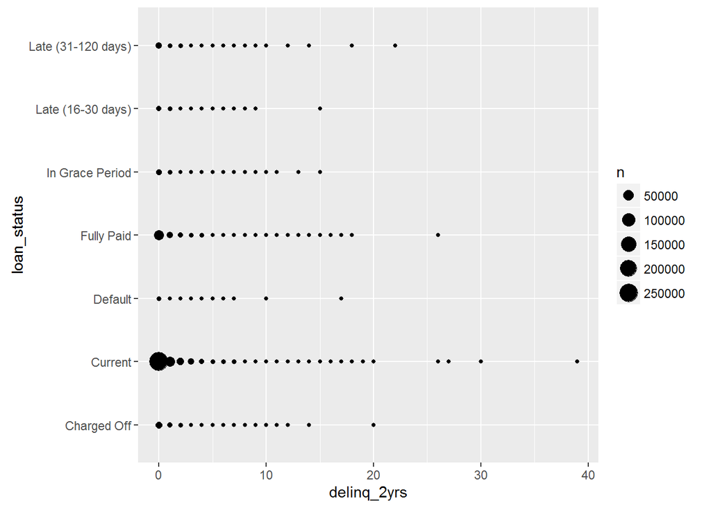

```r
#So there's a very slight pattern of people with low to no delinquencies but very minor # you can argue it is no pattern as its so slight as many pay off their loans have no
# delinquencies but can be a potential wolf in sheets clothing. Maybe its the housing #costs as typically rent or living costs take up to 30-50% of our income!

delinq <- subset(LC,select = c("loan_status","delinq_2yrs") )
ggplot(delinq, aes (x = delinq_2yrs, y =loan_status ))+geom_count()
```

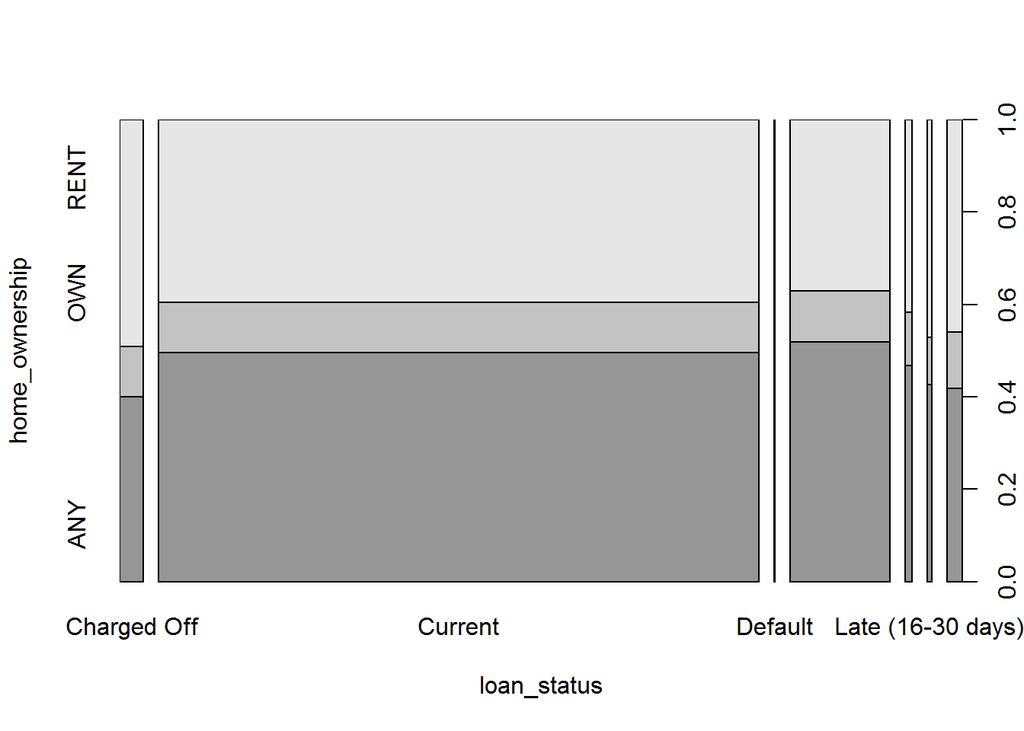

```r
# See no trends here for homeownership, rent or own or in current mortgage. Maybe its #the reason why they borrowed!

homeown <- subset(LC,select = c("loan_status","home_ownership") )
 plot(homeown)
```

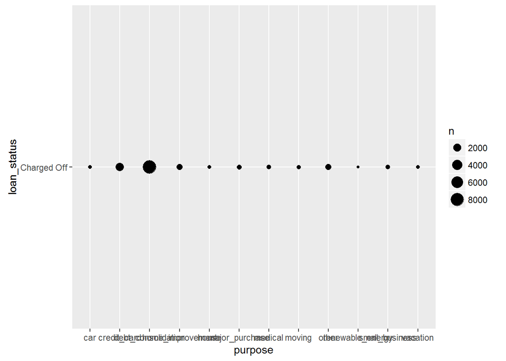

```r
# Looking here I see a ton of credit card and debt consolidation as the biggest reasons # why people are borrowing.

 purpose <- subset(LC,select = c("loan_status","purpose") )
purpose_2 <- subset(purpose, loan_status == "Charged Off")
ggplot(purpose_2, aes (x = purpose, y =loan_status ))+geom_count()
```

```r
summary(purpose_2)
```

```
##              loan_status                  purpose
##  Charged Off       :13325   debt_consolidation:8625
##  Current           :    0   credit_card       :2141
##  Default           :    0   other             : 744
##  Fully Paid        :    0   home_improvement  : 708
##  In Grace Period   :    0   major_purchase    : 280
##  Late (16-30 days) :    0   small_business    : 215
##  Late (31-120 days):    0   (Other)           : 612
```

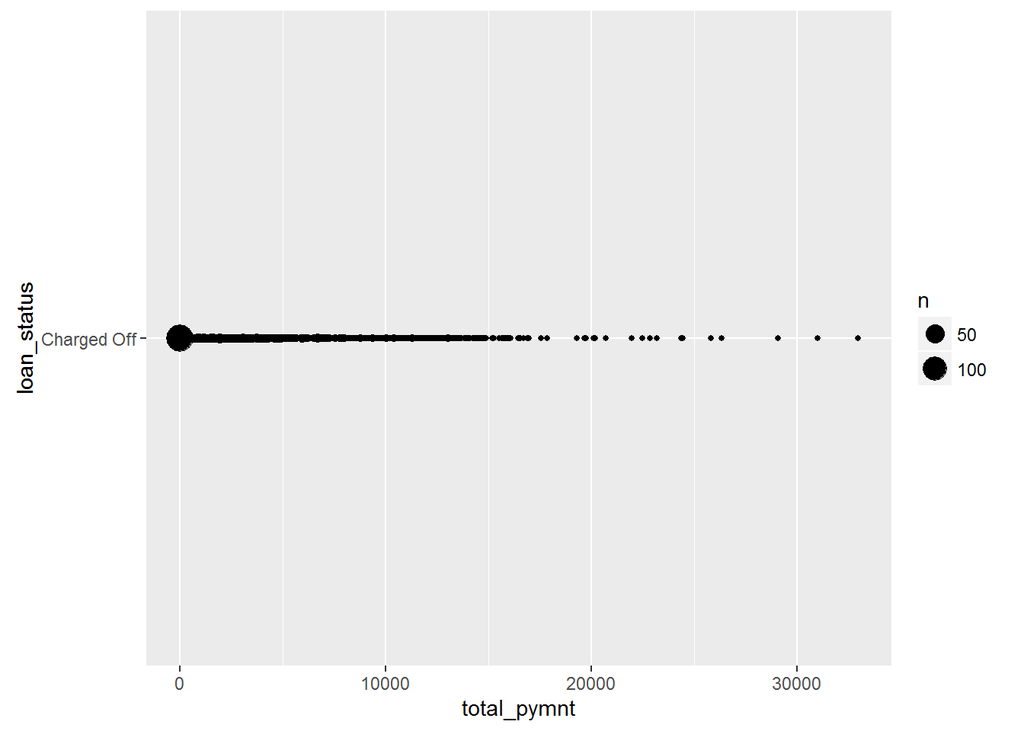

```r
#So what have we learned so far?

#Income/home ownership/ interest rates seem to have no patterns
#Employment lengths/credit inquiried/delinquencies are long on the job but low on the #potential risk of default as none have triggered so far.

#Seems to me so far all the data points to seemingly healthy profile digging a bit more #based on these characteristics, leads me to look for other areas of seemingly healthy #loan profiles like Payments!

#the more payments made, less likely to charge off it looks like. So despite seemingly #healthy profiles people have trouble paying. Is it maybe they are sick? reckless?

total_payment <- subset(LC,select = c ("total_pymnt","loan_status") )
total_payment_2 <- subset(total_payment, loan_status == "Charged Off" )
ggplot(total_payment_2, aes(x= total_pymnt, y= loan_status) ) + geom_count()
```